# Project 1

### Group Members: Vince Miller & Sebastian Salomon

## Abstract

Through the use of data mining we are analyzing hospitalization data collected in 2006 during a twenty-fourth month period. The data is allocated among three data sets and contains information about the hospitalization claims made by members. The information provides the ID of the members, the doctor or specialist, the company issuing the bill, and the member’s primary care physician. The data set also contains basic information about the member such as the gender, age at first claim, and length of stay. The number of claims per member, specialization required, and place where member was treated is also included in the data. In this paper we attempt to give a rigorous analysis of the data, including data summarization (e.g., through visualization), important patterns and trends, and explanations and insights on the interesting trends we find. Insight derived from the process can provide tremendous economic value and more efficient procedures; this is crucial to hospitals, vendors, and patients looking for competitive advantages and for more efficient performances.

## 1. Busines Understanding

- Why is it important to know about claims, medication, days spent in the hospital, and readmission rates? Who is interested in this information? What decisions can be informed using such data?[10 Point]

The hospitalization process starts with the member filing a claim, the claim at that point is registered and the data collection, including when the claim was made, begins. The member will then be attended by a doctor or specialist, described in the Provider ID, based on the member’s needs. The doctor may recommend a place of service (could be from the patient’s home, hospital, lab, ambulance, or from the doctor’s private office). The claim also contains other important info like the patient’s PCP (primary care phisician), the specialty of the treatment, etc. The claim will then proceed and afterward the bill will be issued to the Vendor, the company that issues the bill, which in turn will contact the patient for the bill.

According to the latest survey from the American Hospital Association, more than 71 million individuals in the United States visit a hospital each year. Studies have concluded that in 2006 well over $30 billion was spent on unnecessary hospital admissions. Having a thorough understanding about claims, medication, days spent in the hospital, and readmission rates is extremely benefitial for hospital, healthcare providers, and patients. With comprehensive knowledge of the aforementioned information in conjunction with the use of data mining, health care providers can develop new care plans and strategies to reach patients before emergencies occur; Thus, reducing unnessary hospitalizations. This in turn will increase the health of patients while decreasing the cost of care.

## 2. Data Understanding

- Describe the type of data (scale, values, etc.) for each attribute in the files Members_Y1.csv, Claims_Y1.csv and DayInHospital_Y2.csv. [10 point]

|  | Data Class | # Levels | Levels |
| --- | --- | --- | --- |
| **Claims_Y1** |  |  |  |
| MemberID | integer |  |  |
| ProviderID | integer |  |  |
| vendor | integer |  |  |
| pcp | integer |  |  |
| Year | factor | 1 | Y1 |
| specialty | factor | 12 | Anesthesiology, Diagnostic Imaging, Emergency, General Practice, Internal, Laboratory, Obstetrics and Gynecology, Other, Pathology, Pediatrics, Rehabilitation, Surgery |
| placesvc | factor | 8 | Ambulance, Home, Independent Lab, Inpatient Hospital, Office, Other, Outpatient Hospital, Urgent Care |
| paydelay | integer |  |  |
| LengthOfStay | factor | 13 | , 1- 2 weeks, 1 day, 12-26 weeks, 2- 4 weeks, 2 days, 26+ weeks, 3 days, 4- 8 weeks, 4 days, 5 days, 6 days, 8-12 weeks |
| dsfs | factor | 12 | 0- 1 month, 1- 2 months, 10-11 months, 11-12 months, 2- 3 months, 3- 4 months, 4- 5 months, 5- 6 months, 6- 7 months, 7- 8 months, 8- 9 months, 9-10 months |
| PrimaryConditionGroup | factor | 45 | AMI, APPCHOL, ARTHSPIN, CANCRA, CANCRB, CANCRM, CATAST, CHF, COPD, FLaELEC, FXDISLC, GIBLEED, GIOBSENT, GYNEC1, GYNECA, HEART2, HEART4, HEMTOL, HIPFX, INFEC4, LIVERDZ, METAB1, METAB3, MISCHRT, MISCL1,… |
| CharlsonIndex | factor | 4 | 0, 1-2, 3-4, 5+ |
| **DayInHospital_Y2** |  |  |  |
| memberid | integer |  |  |
| DaysInHospital_Y2 | integer |  |  |
| **Members_Y1** |  |  |  |
| MemberID1 | integer |  |  |
| sex | factor | 2 | F, M |
| AgeAtFirstClaim | factor | 9 | 0-9, 10-19, 20-29, 30-39, 40-49, 50-59, 60-69, 70-79, 80+ |

Table 1: Datatypes and Level information

#### Discussion

The table above shows each variable in their respective dataset. A few variables such as MemberID, ProviderID, vendor, pcp are listed as integer values, but from the data dictionary we know these values should not be considered integers for analysis. These values will be converted to factors. MemberID appears in each dataset, but the column name is slightly different. We will need to remember this if we want to merge. Other integer values paydelay and DaysInHospital represent day counts. These values will be as integers. Lastly, there are many factor variables. Each factor count as well as the factors themselves are listed. A few things to note are year currently has no value considering it is the same for each row, LengthOfStay has missing values, and PrimaryConditionGroup has many factors comparatively. These are our preliminary findings when inspecting the data. I am sure there will be many to come!

- Give simple appropriate statistics (range, mode, mean, median, variance, etc.) for most important attributes in these files and describe what they mean if you find something interesting. [10 points]

|  | Min | Max | Mean | Median | SD |
| --- | --- | --- | --- | --- | --- |
| **df.Claims_Y1** |  |  |  |  |  |
| Pay Delay | 0 | 161 | 43.3686285 | 36 | 30.166422 |
| **df.DayInHospital_Y2** |  |  |  |  |  |
| Days In Hospital Year 2 | 0 | 15 | 0.6649847 | 0 | 2.223792 |

Table 2: Summary statistics of current integer features

#### Discussion

The table above shows the min, max, mean, median, and standard deviation for the two integer variables found in the datasets. An assumption was made that missing values in the pay delay variable represent pay delay of 0. Inspecting the summary statistics for pay delay do not show much interesting information. The variable appears slightly skewed right. Inspecting the Days in Hospital Year 2 is slighly more interesting. The mean is very low considering the range. The standard deviation is also small. This variable appears that it is concentrated at 0. The summary statistics give some insight to these variables, but we can do better sleuthing with visualizations.

|  | Variable (Max) | % | Variable (Min) | % |
| --- | --- | --- | --- | --- |
| **Claims_Y1** |  |  |  |  |
| specialty | Internal | 26.46819 | Pathology | 0.6505291 |
| placesvc | Office | 62.71215 | Home | 0.1527828 |
| LengthOfStay |  | 95.83081 | 12-26 weeks | 0.0013960 |
| dsfs | 0- 1 month | 27.46166 | 11-12 months | 1.6592059 |
| PrimaryConditionGroup | MSC2a3 | 17.29455 | SEPSIS | 0.0186131 |
| CharlsonIndex | 0 | 57.26502 | 5+ | 0.1878376 |
| **Members_Y1** |  |  |  |  |
| sex | F | 54.93796 | M | 45.0620399 |
| AgeAtFirstClaim | 70-79 | 17.14862 | 20-29 | 6.3605429 |

Table 3: A min and max summary for each categorical variable

#### Discussion

The table above shows the max variable, max percent, min variable, and min percent for the count of each categorical variable in the datasets. The length of stay variable has 95% of the variable as an empty string. Reading from the Kaggle description these values were suppressed. This value will be changed to missing later. Home makes up a very small amout of the places variable, and office with greater than 60 percent of observations is the second most dominant value for all the varibles respectively.

- Visualize the most important attributes appropriately. Provide an interpretation for each graph. Explain for each attribute type why you chose the visualization. [10 points]

Below is a plot for each variable as they were found in their respective dataset. This sleuthing is necessary to understand each variable allowing an informed aproach for handling missing values, feature selection, and feature engineering.

### Integer Variable Visualizations

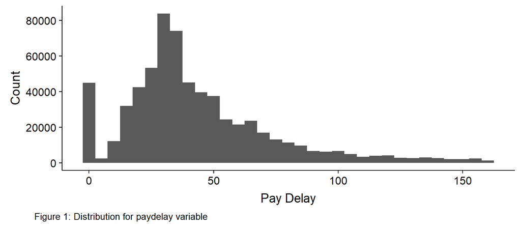

#### Discussion

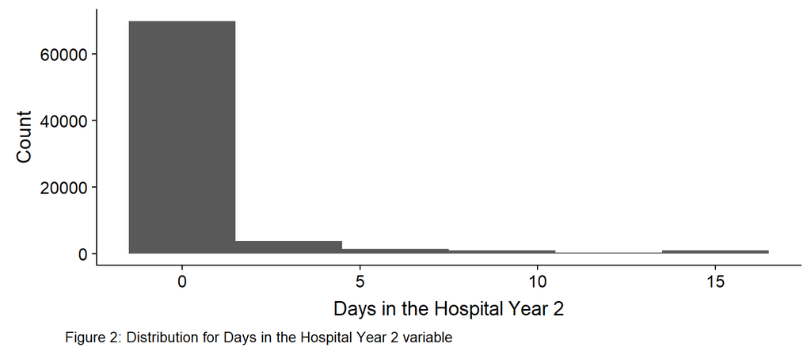

#### Discussion

This variable has alot of concentration at zero. It is odd that there is an uptick at 15. Reading the data dictionary you will find that anything above 15 is top coded to 15.

### Categorical Variable Visualizations

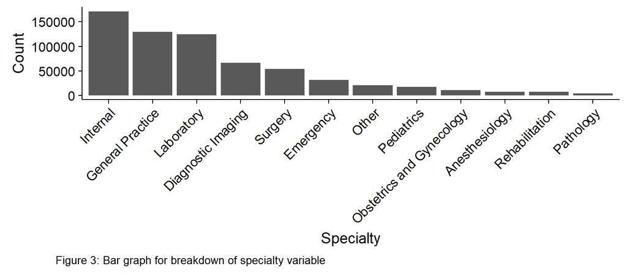

#### Discussion

The bar chart above shows the breakdown of generalized specialty. This variable has great room for improvment. The categories do not appear to be consistent related to the level of specialty they show. The higher categories to the left are not specific, and I believe their broadness is the reason why their count is higher. It is possible that this could be systemic allocation, but I think if possible there would be alot value in digging deeper for the broader categories. Currently the possibilty of overlap will make this variable less informative.

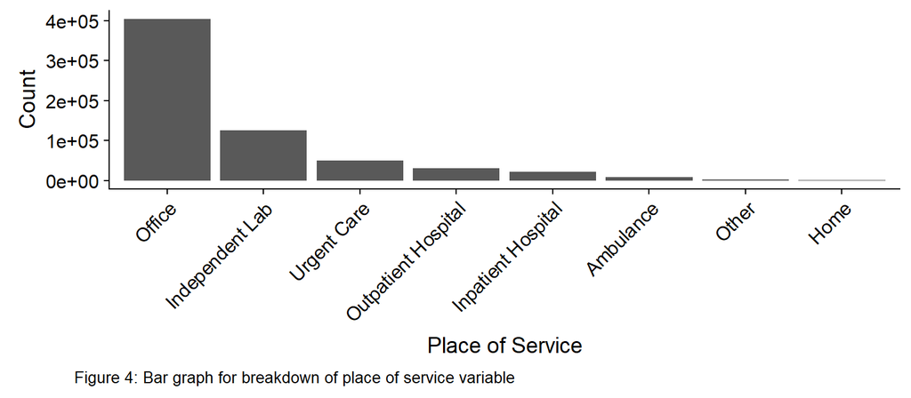

#### Discussion

The barplot above shows the breakdown for place of service. Remember this variable was dominated by Office, and does not appear to have as much possibility for overlap as specialty. This variable has potential for being a good predictor.

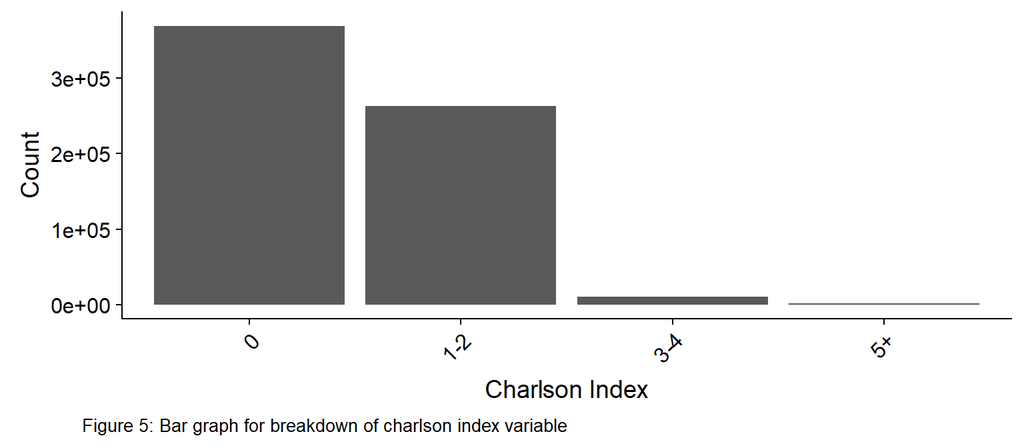

#### Discussion

The Charlson Index is a measure of the particular affect that a disease has on overall illness, grouped by significance, that generalizes additional diagnoses. Scores greater than zero are carried forward (for up to a year) in subsequent claims with a comorbidity score of zero [1,4]. In lay terms, a higher Charlson Index implies a higher probability of 10 year mortality rate of the particular member.

The Charlson Index distribution shown above has an exponential decay trend. This means that the probability of a particular claim on having a high Charlson Index in this particular data set is rare.

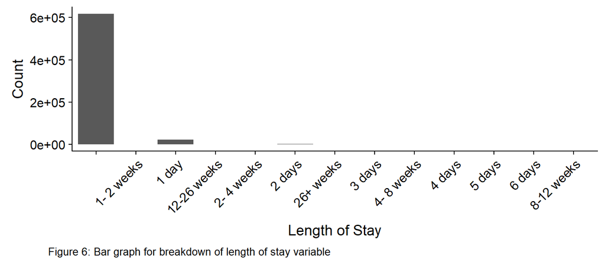

#### Discussion

The breakdown for length of stay shows a clear data quality issue. This is consistent with our breakdwon of the Claims_Y1 dataset showing ~95% of the length of stay variable is empty string. Even though alot of these values are suppressed, converting the days to numerical and aggregating by member Id might show improvement. If this is not successful other options will need to be considered.

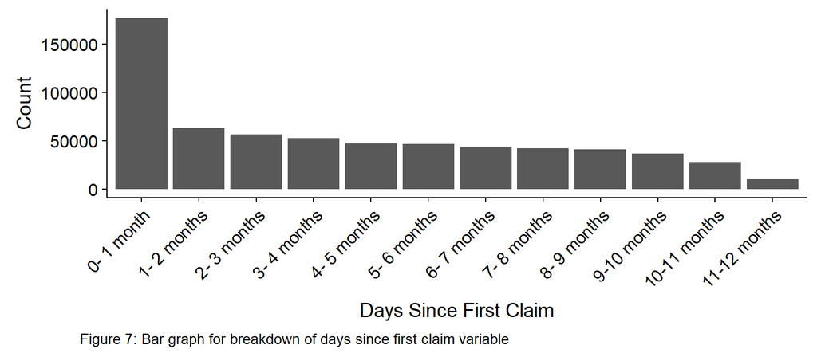

#### Discussion

This breakdown appears to have good data quality. According to the data dictionary the variable represents days since first claim for the current claim in each year. The variable has no missing values, and the first claim is grouped in the 0-1 month category. This was found through our own analysis. This variable is not very intuitve, and possibly relates to annual insurance policy premiums.If this variable is highly correlated with another it could be advantageous to choose the more intuitive option. If not aggregating by memberid after coding the variable as numeric and creating an average number of days between claims could be useful. Additional improvement to the variable might be done by doing a breakdown of the first category, 0-1 month, and first claim by attempting to classify the distinctions.

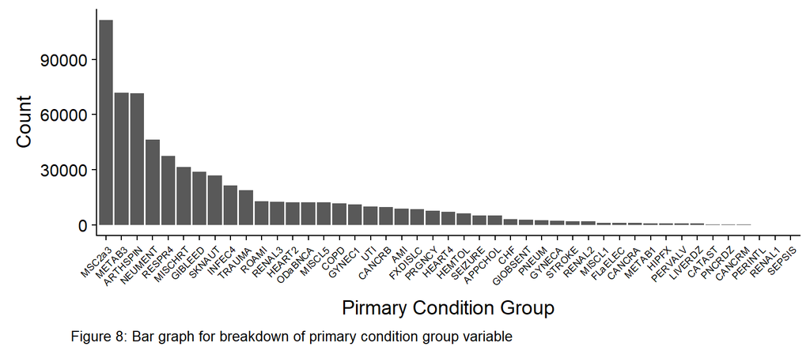

#### Discussion

The primary condition group does not appear to show anything extremely interesting other than some groups are more popular than others. A potential variable to create is an indicator if a member id has used multiple primary condition groups.

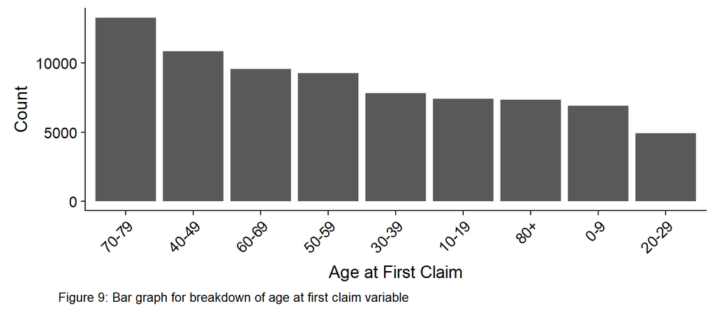

#### Discussion

The breakdown above shows the age at first claim. The largest group of age at first claim is 70-79 group. There is alot that do not have their first claim until they are over 80. That is great! 20-29 is the group that has the least first claims. What a time to be alive!

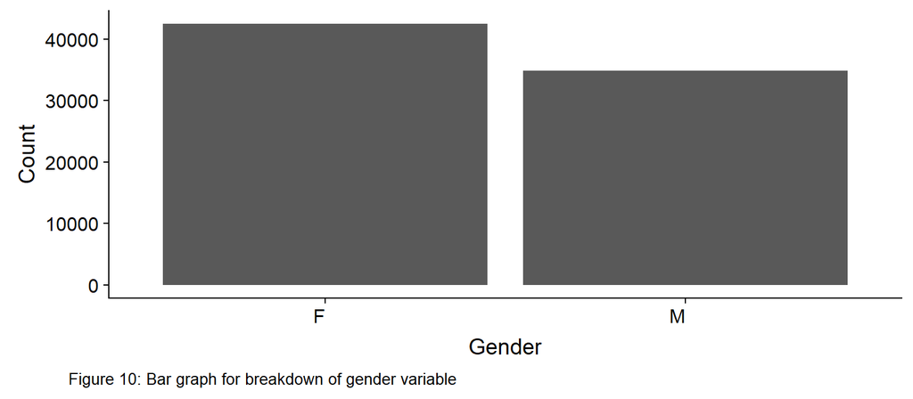

#### Discussion

The gender breakdown above shows a slightly lopsided breakdown in favor of the females. That means that there were more females than males with a memberID. It is also important to take account the amount of claims made from each individual, and by doing some data mapping we found that females in average made 8.925 claims per individual. In turn males in average filed 7.63 claims per individual. That means that the claims breakdown by males to females is a little more lopsided than the one shown above.

- Explore relationships between attributes: Look a the attributes and then use cross-tabulation, correlation, group-wize averages, etc. as appropriate. [10 points]

Our initial approach is to view relationships between variables that have confirmed high quality above. Visualizing the relationships between the high quality varibles can be insightful for comparing while we attempt to handle fixing data quality issues. Relationships between variables that contain data quality issues can be viewed after they are adjusted in the next section.

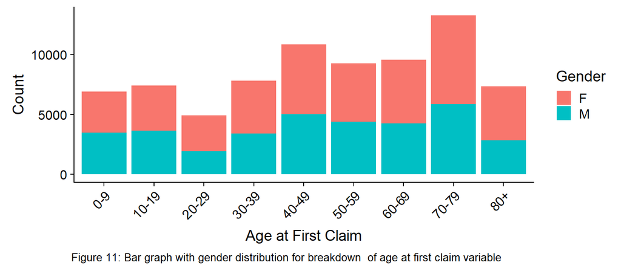

#### Discussion

The plot above shows that the distribution of sex across the age at first claim is near the expected value. This helps the assumption that there was randoming sampling as related to age at first claim and sex from the members dataset. If the members data set had very different distribution of sex across age at first claim we could suspect bad sampling methods.

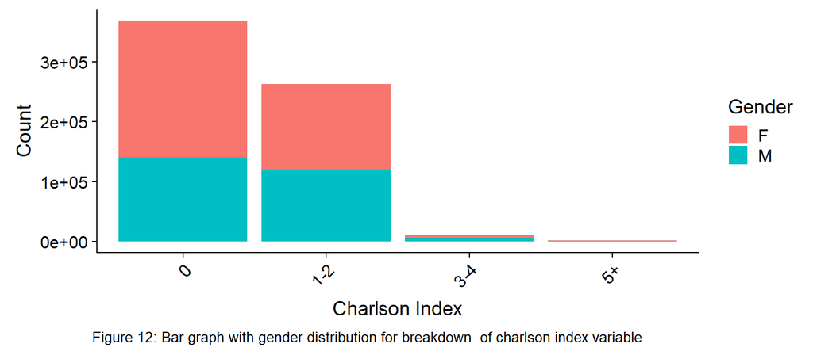

#### Discussion

This plot is interesting because while we know there are more females, and we’ve stated that on average females have more claims per individual we can clearly see that the proportion of males and females in each Charlson Index is not normal. Females appear to claim less severe incidents as reported by the Charlson Index. Investigating the distributions for days spent in the hospital during year 2 for male and female show slightly different distributions. The table below shows that females have a slightly higher mean for days spent in the hospital than males. This is interesting given our knowledge of the severity of their claims. This prior information could be useful for hospitals as they budget resources given expected claims by gender over time.

|  | Female | Male |
| --- | --- | --- |
| Mean | 0.7122536 | 0.6073562 |

Table 4: Mean days spent in the hospital during year 2 by gender

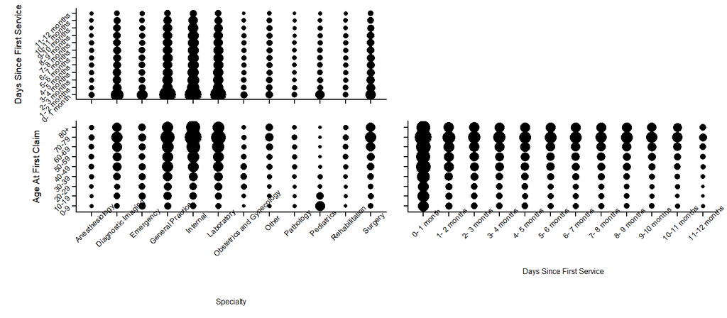

Figure 13: Joint variable density plots between age at first claim, days since first service, and specialty

#### Discussion

The charts above show interactions between specialty, days since first service, and age at first claim. Age at first claim was merged to the Claims_Y1 dataset. Age at first claim is repeated for the specific memberid that it corresponds with within the Claims_Y1 dataset.

This chart shows the concentration of the claims as it relates to these categorical variables e.g. the observations that have higher age at first claim concentrate in general practice, internal, and laboratory for the specialty variable. The 0-1 months category for days since first claim is the category that seems least affected when varying specialty. The 0-1 month category is also least effected when comparing across age at first claim i.e. if the days since first claim is high it is more likely that the age when the first claim was made is also high.

The first of two main interpretations of this plot is that if the days since first claim is greater than 1 month or the age at first claim is high the specialty is most likely general practice, internal, or laboratory. A fair assumption is that higher age at first claim corresponds to older individuals when compared to the younger age at first claim groups. That makes the first interpretation logical. Older individuals with longer periods between claims probably have regularly scheduled appointments that would take place at these locations. The second interpretation is that lower age at first claim have lower days since first claim and varying specialty. This makes sense that younger individuals have more variable claims related to specialty, and it appears that their next claim occurs faster. This makes sense that someone who is willing to make a claim earlier on in life will have a shorter period before their next claim.

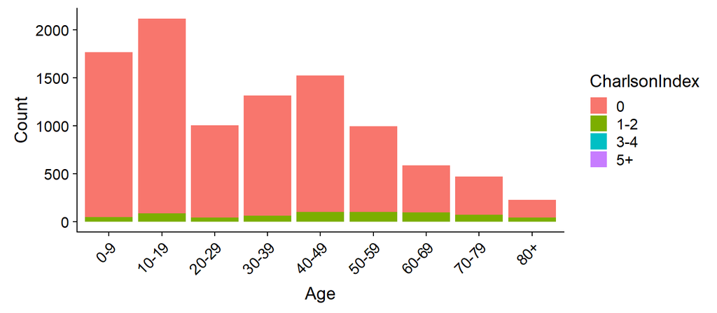

Figure 14: Bar graph with charlson index distribution for breakdown of age when first claim variable

#### Discussion

This plot is interesting because in this one we get roughly the age of the individual. The way this was done was by manipulating the data in order to get only the individuals that have made one claim, therefore the age of their first claim is the same age that they had when they filed that particular claim. By looking at the plot we can notice a positive correlation between the Charleson Index and the age of the individual. What this means is that if you are getting a young and an old individual filing a claim, the older individual is on average more likely to have a higher Charlson Index.

This plot cannot be used to verify the assumptions from the previous plot. Our previous assumption is that younger indiviuals will have claims that require follow ups more quickly. Assuming more severe claims have quicker follow ups the chart above does not show this except you cannot gain an understanding from the charlson index if the high charlson index is due to the claim or the age of the person. A variable that could be made to understand the severity of the claim is the rate of change or increase of the charlson index between claims.

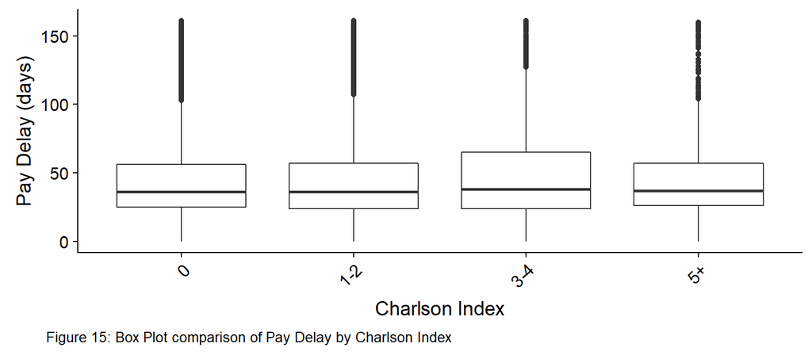

#### Discussion:

This box plot shows us the distribution of each of the 4 different Charlson Index with respect to the pay delay. I was orginially expecting to be more delay on the higher indexes, but the graph shows each of the medians to be very similar between each other. The distribution also tells us that there are more people who pay later than right away since the the upper quartile is bigger than the 1st quartile.

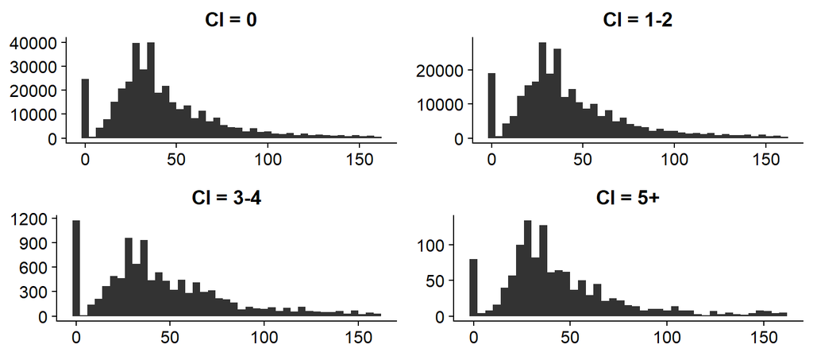

Figure 16: Distribution of pay delay for each charlson index

#### Discussion:

This graph above displays the histogram of paydelay according to each unique Charlson Index value. What is very interesting about the results is that the distribution remain extremely similar regardless of the CI, even taking into account that each of the graphs have very different counts. All of the graphs are right skewed and this is expected since the value of paydelay cannot be less than 0. The graphs also have a truncated distribution, these might be the result of vendors not processing payments on the weekends. We can notice 3 unique high points in most of the graphs. One is at the beginning at 0, this is expected since many of the patients pay at the moment of getting their service. The two other spikes lie in the days 31-33 and 37-39. Further studying these points in particular could provide insight in trying to reduce the pay delay.

- Verigy data quality: Are there missing values? Duplicate Data? Outliers? Are those mistakes? How can these be fixed? [10 points]

#### Discussion

When that datasets were first read an analysis of the key values was performed. It was found that df.Members & df.DayInHospital_Y2 shared exactly the same unique values for memberID. Also, when compared with the unique values of df.Claims_Y1 the memberid was exactly the same. These checks were necessary to ensure no data was lost during merging.

Next, an analysis of ther percent missing was performed. Table 5 shows the details of missing values for the dataset.

|  | Percent_Missing |
| --- | --- |
| **Claims_Y1** |  |
| MemberID | 0.00 |
| ProviderID | 0.61 |
| vendor | 1.01 |
| pcp | 0.25 |
| Year | 0.00 |
| specialty | 0.00 |
| placesvc | 0.00 |
| paydelay | 6.92 |
| LengthOfStay | 95.83 |
| dsfs | 0.00 |
| PrimaryConditionGroup | 0.00 |
| CharlsonIndex | 0.00 |
| **Members_Y1** |  |
| MemberID1 | 0.00 |
| sex | 0.00 |
| AgeAtFirstClaim | 0.00 |
| **DayInHospital_Y2** |  |
| DaysInHospital_Y2 | 0.00 |
| MemberID2 | 0.00 |

Table 5: Describing the missing values for each variable

#### Discussion

The data quality for the dataset is not bad. The daysinhospital_Y2 and Members_Y1 dataset has no missing values. The claims_y1 has some missing values. Pay delay has ~7 percent of values missing. We mentioned earlier we will treat these as 0. We are assuming these people paid on time. Changed empty string in length of stay to missing. The Kaggle project description said that these values are suppressed therefore we will treat as missing. ProviderID, vendor, and pcp have minimal missing values. We could probably delete these observations, and move forward noting this decision in case later we want to re visit them.

Also, duplicate data and outliers were considered. No duplicate rows were found in the three datasets. The first assesment of outliers existed in Table 3 where a summary of the categorical variables, and the min for each category was noted. Second, the integer variables were assesed. Paydelay and daysinhospital_y2 were capped, but pay delay does have exterme values. This will need to be considered when we begin modeling.

## 3. Data Preperation

- Create additional attributes (columns) which might be of interest. For example, for each pation it might be interesting how many claims were filed. Maybe the claims need to be categorized? [20 points]

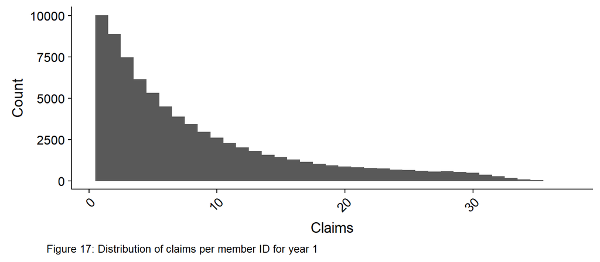

#### Discussion

This distribution shows claims per member id during year 1. This gives good insight to the frequency of claims, and shows that most memberid have greater than 1 claim.

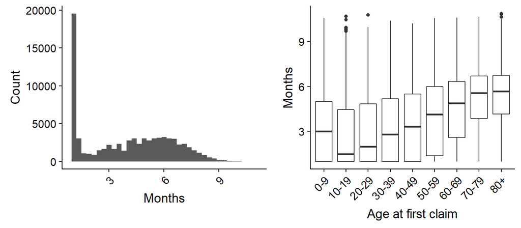

Figure 18: Distribution of mean months since first claim per member ID, and average mean months across age at first claim for year 1

#### Discussion

The mean months since first service variable is zero inflated. This is in part because first claims are coded the same as being within 1 month of the first claim. As mentioned before we may need to try to fix this. Viewing the boxplot on the right we can see that on average those whose age at first claim is higher usually results in larger time since first claims. This is similar to our thoughts above that those with higher age at first claim are likely to have less claims, and now we can see they have on average longer time between claims. Since this variable is since the first claim this could be due to the fact they have more claims, and claims take time.

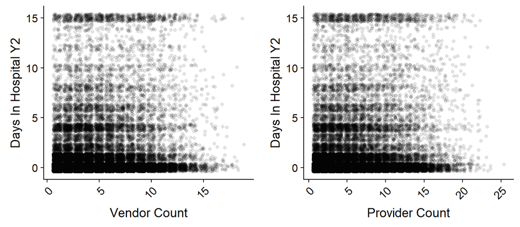

Figure 19: Correlation between the days in hospital during year 2 and counts of vendor (left) & provider (right)

#### Discussion

The count of vendor and the count of provider per member id varibles were created. The variables are very similar to one another, and their relationship to days in hospital during year 2 is also similar. This could be due to the fact that switching providers mostly results in changing vendors. This chart also shows how the capping of the days in hospital during year 2 can cause for un natural correlation with variables.

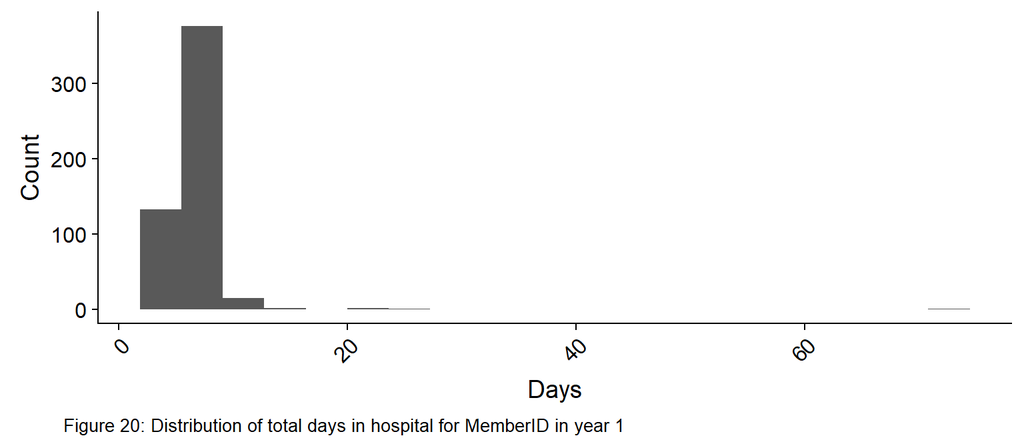

#### Discussion

This plot was creating using the sum of length of stay for each MemberID. The median total days spent in the hospital for the non suppressed values is ~6. The sparsity of the original length of variable is seen even after adding up the days for each member ID. The sum was calculated for less than 1000 of the 77289 unique MemberIDs. Even with the sparsity the fact that a variable is not missing could have significance.

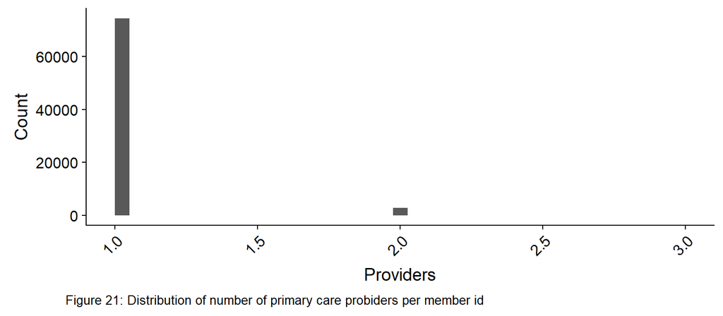

#### Discussion

This plot shows the distribution for primary provider count per member id. There are approximately 2000 members that have more than 1 primary care provider in year 1. This count variable could provide predictive power if the number of providers is associated with more or less days in the hospital during year 2.

Above the figures and discussions show 6 variables that we have created and merged on the members dataset. These variables will be useful if we would like to use the member level for predicting days in the hospital during year 2. Feature engineering is an iterative process, and there are many possibilites for the variables we create. After the modeling process has began we can revisit our variables, and add or remove variables as we see fit.

## Exceptional Work

Our group completed the entire project in R markdown. The group was required to learn some html for formating as well as R libraries that create tables. These new skills can be used for our next project, and while it took extra time for this report should pay off in the end.

#### Conclusion

This paper went through deep analysis of the hospitalization data set. We described the business understanding of the hospitalization process, specifically gave the benefits that data mining can give to the whole hospitalization process. We also gave a thorough description of each of the variables, using summarization and with visualization. Finally, we went through data preparation for future modeling purposes.  
At this moment in time we cannot provide definite recommendations to hospitals, vendors, or patients since further modeling and analysis is necessary to make sure that the trends we are currently getting are not by chance.